# Práctica 1 - Minería de Datos

Igualmente probemos un poco de codigo lineal:

```
##
## ==============================
## 📊 Evaluando: Ki67 como predictor de TAMAÑO
## 🔹 Coeficiente: -2e-04 → Relación negativa
## 🔹 p-valor: 0.93443 → ❌ No significativa
## 🔹 R²: 0 → ❗ Explica poco
```

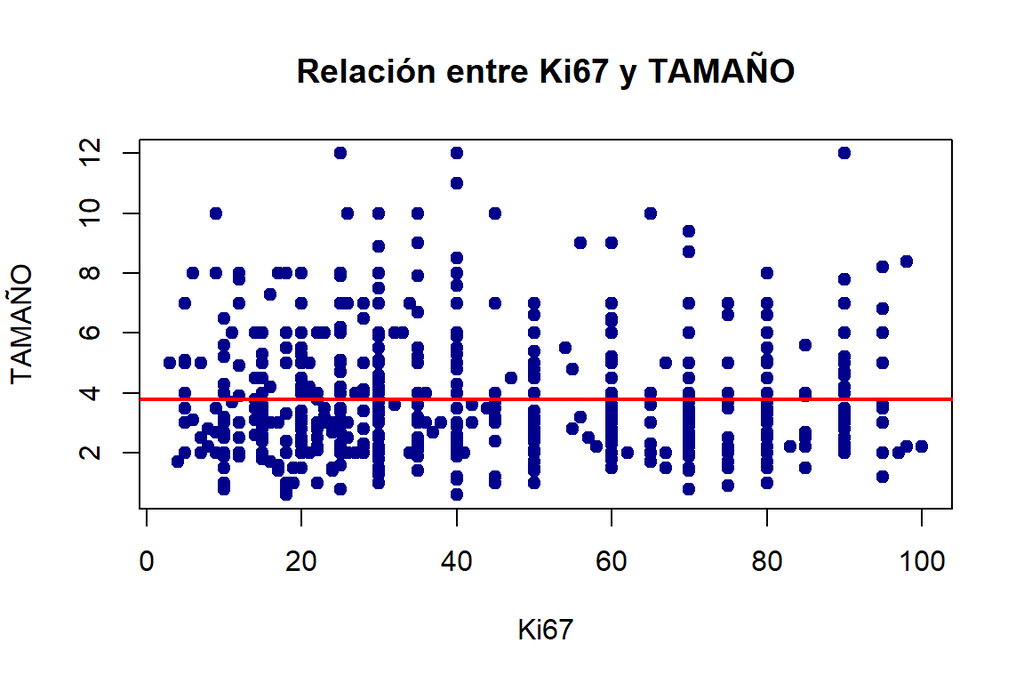

```
## 🔮 Predicciones para valores de Ki67 :
##   Ki67 Prediccion_Tamaño
## 1  -50              3.81
## 2    0              3.80
## 3   15              3.80
## 4   50              3.79
## 5  120              3.77
## 6  200              3.75
##
## ==============================
## 📊 Evaluando: EDAD_DIAGNOSTICO como predictor de TAMAÑO
## 🔹 Coeficiente: 0.0027 → Relación positiva
## 🔹 p-valor: 0.67604 → ❌ No significativa
## 🔹 R²: 0 → ❗ Explica poco
```

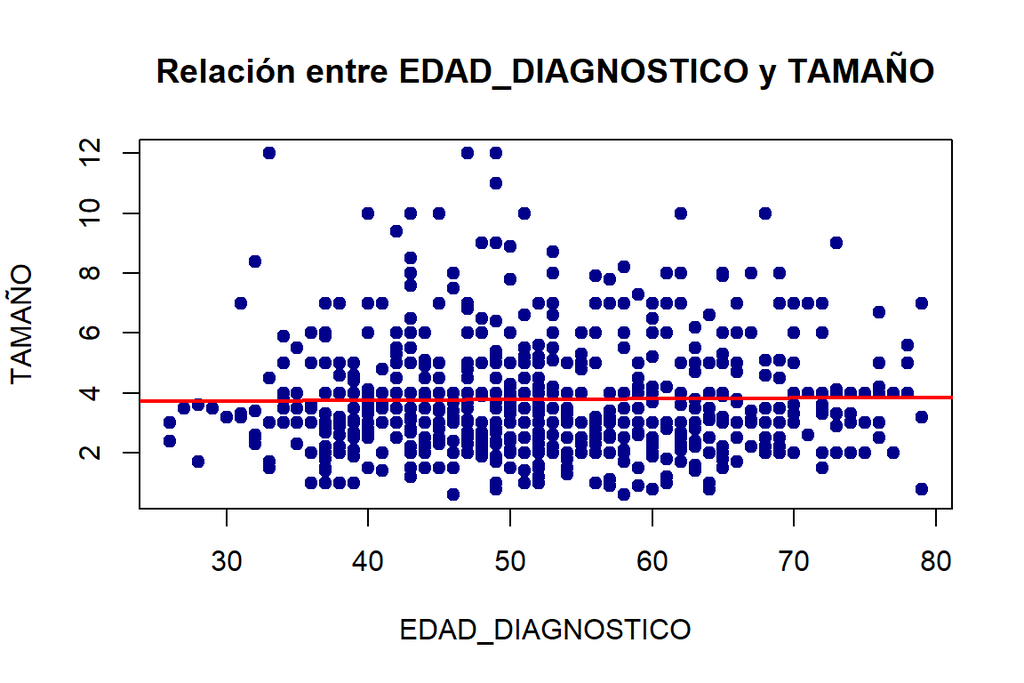

```
## 🔮 Predicciones para valores de EDAD_DIAGNOSTICO :
##   EDAD_DIAGNOSTICO Prediccion_Tamaño
## 1            26.00              3.72
## 2            39.25              3.75
## 3            52.50              3.79
## 4            65.75              3.83
## 5            79.00              3.86
##
## ==============================
## 📊 Evaluando: No_ANTIBIOTICOS como predictor de TAMAÑO
## 🔹 Coeficiente: -0.0818 → Relación negativa
## 🔹 p-valor: 0.33613 → ❌ No significativa
## 🔹 R²: 0.001 → ❗ Explica poco
```

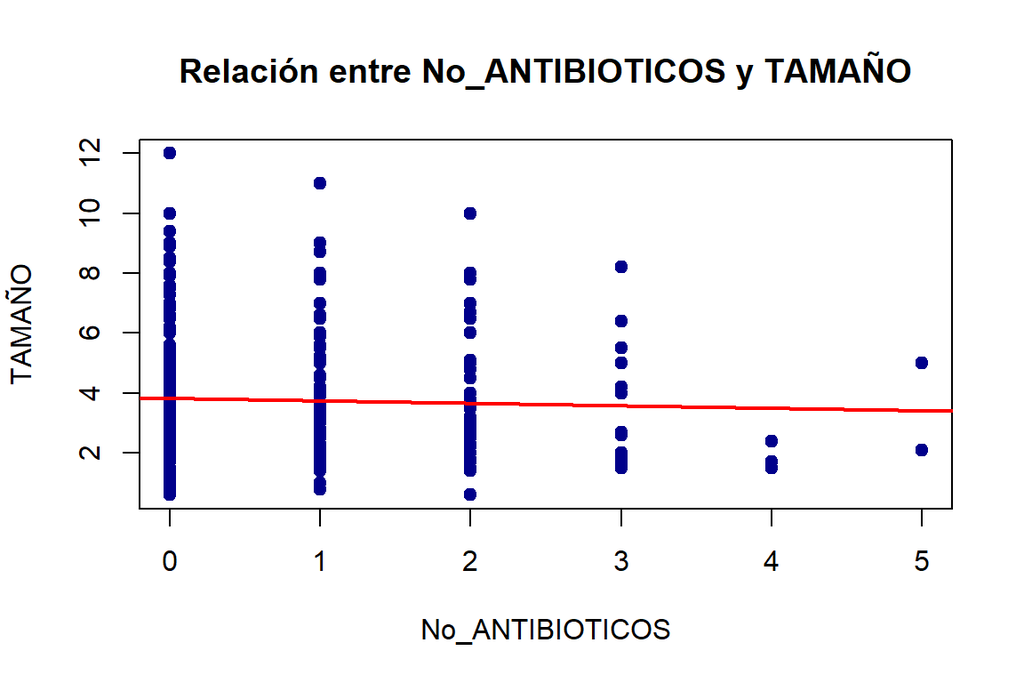

```
## 🔮 Predicciones para valores de No_ANTIBIOTICOS :
##   No_ANTIBIOTICOS Prediccion_Tamaño
## 1            0.00              3.84
## 2            1.25              3.73
## 3            2.50              3.63
## 4            3.75              3.53
## 5            5.00              3.43
##
## ==============================
## 📊 Evaluando: RE como predictor de TAMAÑO
## 🔹 Coeficiente: 5e-04 → Relación positiva
## 🔹 p-valor: 0.77202 → ❌ No significativa
## 🔹 R²: 0 → ❗ Explica poco
```

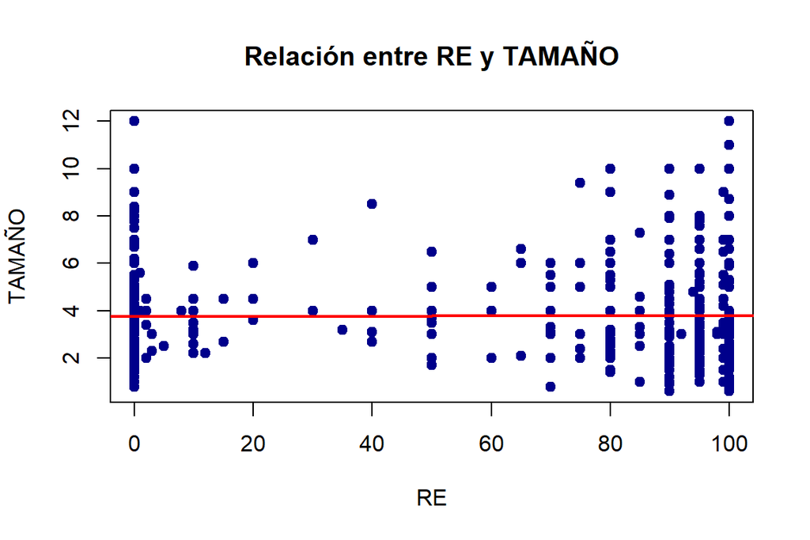

```
## 🔮 Predicciones para valores de RE :
##    RE Prediccion_Tamaño
## 1   0              3.77
## 2  25              3.78
## 3  50              3.79
## 4  75              3.80
## 5 100              3.81
##
## ==============================
## 📊 Evaluando: RP como predictor de TAMAÑO
## 🔹 Coeficiente: 3e-04 → Relación positiva
## 🔹 p-valor: 0.88879 → ❌ No significativa
## 🔹 R²: 0 → ❗ Explica poco
```

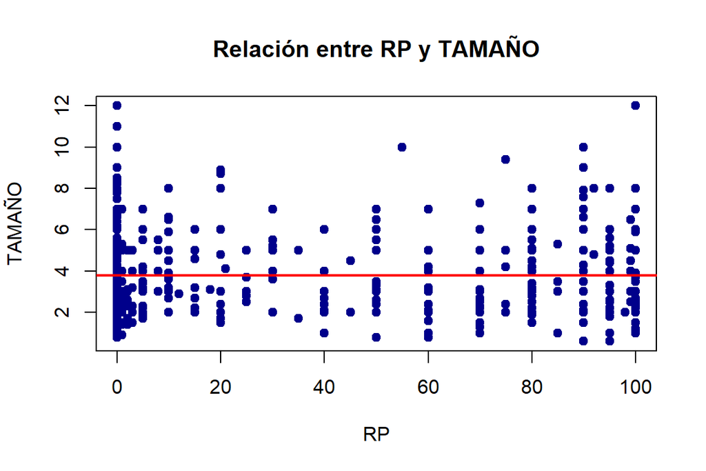

```
## 🔮 Predicciones para valores de RP :
##    RP Prediccion_Tamaño
## 1   0              3.78
## 2  25              3.79
## 3  50              3.80
## 4  75              3.80
## 5 100              3.81
```

```r
library(ggplot2)

# Variables que quieres evaluar como predictoras de TAMAÑO
vars_numericas <- c("Ki67", "EDAD_DIAGNOSTICO", "No_ANTIBIOTICOS", "RE", "RP")

# Bucle por cada variable
for (var in vars_numericas) {
  cat("\n==============================\n")
  cat("📊 Evaluando:", var, "como predictor de TAMAÑO\n")

  # Verificar si la variable es numérica
  if (is.numeric(datos[[var]])) {
    # Modelo lineal
    formula_str <- as.formula(paste("TAMAÑO ~", var))
    mod_lin <- lm(formula_str, data = datos)
    resumen <- summary(mod_lin)

    # Extraer valores clave
    coeficiente <- resumen$coefficients[2, 1]
    p_valor <- resumen$coefficients[2, 4]
    r2 <- resumen$r.squared

    # Interpretación
    direccion <- ifelse(coeficiente > 0, "positiva", "negativa")
    significancia <- ifelse(p_valor < 0.05, "✅ Significativa", "❌ No significativa")

    cat("🔹 Coeficiente:", round(coeficiente, 4), "→ Relación", direccion, "\n")
    cat("🔹 p-valor:", round(p_valor, 5), "→", significancia, "\n")
    cat("🔹 R²:", round(r2, 3), "→", ifelse(r2 > 0.3, "✔ Explica bastante", "❗ Explica poco"), "\n")

    # Gráfico solo si ambas son numéricas
    plot(datos[[var]], datos$TAMAÑO,
         main = paste("Relación entre", var, "y TAMAÑO"),
         xlab = var, ylab = "TAMAÑO",
         col = "darkblue", pch = 19)
    abline(mod_lin, col = "red", lwd = 2)

    # Predicción con valores teóricos
    nuevos_valores <- data.frame()
    if (var == "Ki67") {
      nuevos_valores <- data.frame(Ki67 = c(-50, 0, 15, 50, 120, 200))
    } else {
      nuevos_valores <- data.frame(x = seq(min(datos[[var]], na.rm = TRUE),
                                           max(datos[[var]], na.rm = TRUE),
                                           length.out = 5))
      names(nuevos_valores) <- var
    }

    predicciones <- predict(mod_lin, newdata = nuevos_valores)
    cat("🔮 Predicciones para valores de", var, ":\n")
    print(data.frame(nuevos_valores, Prediccion_Tamaño = round(predicciones, 2)))
  } else {
    cat("La variable", var, "no es numérica. No se puede ajustar modelo lineal ni graficar.\n")
  }
}
```

Se realizaron regresiones lineales simples del tipo TAMAÑO ~ X. En cada caso, se interpretó el signo del coeficiente (para identificar si la relación era positiva o negativa), el p-valor (para valorar significancia estadística) y el R² (para cuantificar cuánta variabilidad del tamaño explica la variable predictora).

Los resultados muestran que:

EDAD_DIAGNOSTICO tiene una relación positiva débil con TAMAÑO (coef. = 0.0027), pero no significativa (p = 0.676), y un R² ≈ 0, por lo que no se considera un buen predictor.

No_ANTIBIOTICOS presenta una relación negativa leve con TAMAÑO (coef. = -0.0818), pero tampoco significativa (p = 0.336), y su R² es muy bajo (0.001), lo que indica nula capacidad explicativa.

RE y RP, marcadores hormonales, muestran coeficientes positivos mínimos, sin significancia estadística (p > 0.7) ni capacidad predictiva (R² ≈ 0). Por tanto, se descartan como predictores de TAMAÑO en este contexto.

## 6.1 Regresión logística

Este problema se soluciona utilizando regresión logística, una técnica específicamente diseñada para variables dependientes binarias. Esta metodología transforma la combinación lineal de los predictores en probabilidades válidas usando una función logística (o sigmoidea), que restringe los valores entre 0 y 1. En lugar de modelar directamente la media de la variable dependiente, la regresión logística estima la probabilidad de ocurrencia del evento en función de las variables explicativas. Por tanto, en nuestro contexto, el modelo estima la probabilidad de que un paciente logre una RCP en función de factores clínicos como el tamaño del tumor, el grado histológico y el uso de antibióticos.

Los coeficientes del modelo indican la dirección y magnitud de esta relación: un valor positivo implica que a medida que aumenta la variable predictora, también lo hace la probabilidad de RCP, mientras que un coeficiente negativo indica lo contrario. Estos efectos se interpretan más fácilmente a través del odds ratio (OR), que cuantifica cuánto se multiplican las probabilidades de respuesta por cada unidad de cambio en la variable independiente. Por ejemplo, un OR menor a 1 indica una disminución en la probabilidad del evento, y uno mayor a 1, un aumento. La significancia estadística de cada predictor se evalúa con el p-valor: si es menor a 0.05, el efecto se considera significativo. Además, la devianza residual y el AIC se utilizan para evaluar la calidad del modelo: cuanto más bajos, mejor ajuste.

Ahora, ajustamos un modelo con el siguiente código:

```r
modelo <- glm((RCP_1 == "SI") ~ TAMAÑO + GRADO_CAT + ANTIBIOTICO, data = datos, family = binomial)
summary(modelo)
```

```
##
## Call:
## glm(formula = (RCP_1 == "SI") ~ TAMAÑO + GRADO_CAT + ANTIBIOTICO,
##     family = binomial, data = datos)
##
## Deviance Residuals:
##     Min       1Q   Median       3Q      Max
## -1.1403  -0.9149  -0.7420   1.3009   1.9600
##
## Coefficients:
##               Estimate Std. Error z value Pr(>|z|)
## (Intercept)   -0.72107    0.21397  -3.370 0.000752 ***
## TAMAÑO        -0.09892    0.04522  -2.188 0.028701 *
## GRADO_CAT3     0.73212    0.17024   4.301  1.7e-05 ***
## ANTIBIOTICOSI -0.26980    0.17169  -1.571 0.116084
## ---
## Signif. codes:  0 '***' 0.001 '**' 0.01 '*' 0.05 '.' 0.1 ' ' 1
##
## (Dispersion parameter for binomial family taken to be 1)
##
##     Null deviance: 870.73  on 698  degrees of freedom
## Residual deviance: 846.16  on 695  degrees of freedom
## AIC: 854.16
##
## Number of Fisher Scoring iterations: 4
```

El intercepto del modelo tiene un valor negativo significativo (−0.72107, p ≈ 0.00075), lo que indica que, en condiciones de referencia (tumores de grado 1/2 y sin antibióticos, con tamaño igual a 0), la probabilidad base de lograr una RCP es baja.

En cuanto al tamaño del tumor, su coeficiente (−0.09892, p ≈ 0.0287) es negativo y significativo, lo que sugiere que a mayor tamaño tumoral, menor probabilidad de alcanzar una RCP. Al convertirlo a OR → exp(−0.09892) ≈ 0.906, se concluye que por cada cm adicional en el tamaño del tumor, los odds de RCP disminuyen aproximadamente un 9.4%, lo cual es clínicamente coherente.

En la salida del modelo de regresión logística, el término `GRADO_CAT3` aparece porque R convierte automáticamente las variables categóricas en variables indicadoras (también llamadas dummies) al construir el modelo. En este caso, la variable `GRADO_CAT` tiene dos niveles: `"1/2"` y `"3"`. R toma por defecto el primer nivel como referencia (en este caso `"1/2"`) y crea una nueva variable binaria (`GRADO_CAT3`) que vale 1 cuando el tumor es de grado 3 y 0 cuando es de grado 1 o 2. Por tanto, el coeficiente estimado para `GRADO_CAT3` refleja el cambio en los log-odds de alcanzar una respuesta completa patológica (RCP) cuando el tumor es de grado 3 en comparación con el grupo de referencia (grado 1/2). Esta codificación es estándar en regresión logística y permite interpretar fácilmente los efectos de cada categoría respecto a la base.

Para el grado histológico, se observa que los tumores de grado 3 tienen un coeficiente positivo y altamente significativo (0.73212, p < 0.0001), con un OR ≈ exp(0.73212) ≈ 2.08. Esto significa que los pacientes con tumores de grado 3 tienen más del doble de odds de lograr una RCP en comparación con aquellos de grado 1 o 2. Este hallazgo sugiere que, aunque los tumores de alto grado son más agresivos, también podrían ser más sensibles a la quimioterapia.

Por su parte, el uso de antibióticos (categoría “SI”) muestra un coeficiente negativo (−0.26980), lo cual indicaría una disminución en la probabilidad de RCP; sin embargo, esta asociación no es estadísticamente significativa (p ≈ 0.116), por lo que no se puede concluir con seguridad que el uso de antibióticos influya directamente en la respuesta completa.

El modelo presenta una reducción moderada en la devianza (de 870.73 a 846.16), lo que sugiere que los predictores aportan cierta capacidad explicativa respecto a la variable dependiente. El AIC (854.16) puede utilizarse como referencia para comparar este modelo con otros más complejos o simplificados.

En resumen, este modelo confirma que tanto el tamaño tumoral como el grado histológico son predictores estadísticamente significativos de la respuesta completa patológica, mientras que el uso de antibióticos, aunque presenta una tendencia negativa, no alcanza significancia estadística. Estos hallazgos refuerzan la importancia de estos factores en la estratificación clínica y el diseño de estrategias terapéuticas personalizadas.

Este análisis pone en evidencia una de las grandes ventajas del enfoque multivariante: permite evaluar el efecto de cada variable ajustando por el resto, corrigiendo así posibles sesgos de confusión. Además, nos permite detectar relaciones que no serían visibles en análisis por separado. Esta información es clave para seleccionar variables en un modelo multivariante más robusto y evitar introducir ruido al incluir variables no significativas o redundantes.

### 6.1.1 Selección de Variables con Regresión Stepwise en R

Tras el análisis bivariante exhaustivo presentado en secciones anteriores identificamos un conjunto de variables clínicamente relevantes y estadísticamente significativas en relación con la respuesta completa patológica (RCP_1). Las variables con mayor consistencia estadística y sustento clínico fueron: TAMAÑO, GRADO_CAT, Ki67_CAT, HT_ADY_OK, ANTIBIOTICO, FENOTIPO_IHQ, RT, Tn, Nx.

Para la construcción del modelo, utilizamos el procedimiento de selección de variables stepwise (por pasos), una técnica iterativa que permite construir un modelo parsimonioso y estadísticamente óptimo. Esta metodología evalúa sistemáticamente el impacto de añadir o eliminar cada variable candidata con base en un criterio de información: en este caso, el Akaike Information Criterion (AIC). Cuanto menor es el AIC, mejor es el balance entre calidad del ajuste y complejidad del modelo.Existen tres variantes:

-*Forward selection*: parte de un modelo vacío e incorpora variables una a una si mejoran el ajuste.

-*Backward elimination*: parte del modelo completo y elimina variables si su exclusión mejora el AIC.

-*Stepwise (bidireccional)*: combina los dos métodos anteriores, añadiendo o eliminando variables según el ajuste.

```r
library(MASS)
# Codificación binaria de la variable dependiente
datos$RCP_bin <- ifelse(datos$RCP_1 == "SI", 1, 0)

# Modelo nulo (sin predictores)
modelo_null <- glm(RCP_bin ~ 1, data = datos, family = binomial)

# Modelo completo con variables seleccionadas del análisis bivariante
modelo_full <- glm(RCP_bin ~ TAMAÑO + GRADO_CAT + ANTIBIOTICO + FENOTIPO_IHQ + T + RT ,
                   data = datos, family = binomial)



# Aplicación de los tres métodos de selección
modelo_forward <- stepAIC(modelo_null,
                          scope = list(lower = modelo_null, upper = modelo_full),
                          direction = "forward")
```

```
## Start:  AIC=872.73
## RCP_bin ~ 1
##
##                Df Deviance    AIC
## + FENOTIPO_IHQ  2   798.07 804.07
## + GRADO_CAT     1   853.45 857.45
## + TAMAÑO        1   867.05 871.05
## <none>              870.73 872.73
## + ANTIBIOTICO   1   869.00 873.00
## + RT            1   869.09 873.09
## + T             3   868.90 876.90
##
## Step:  AIC=804.07
## RCP_bin ~ FENOTIPO_IHQ
##
##               Df Deviance    AIC
## + GRADO_CAT    1   791.44 799.44
## + TAMAÑO       1   793.09 801.09
## + ANTIBIOTICO  1   795.82 803.82
## <none>             798.07 804.07
## + RT           1   796.84 804.84
## + T            3   796.84 808.84
##
## Step:  AIC=799.44
## RCP_bin ~ FENOTIPO_IHQ + GRADO_CAT
##
##               Df Deviance    AIC
## + TAMAÑO       1   785.48 795.48
## + ANTIBIOTICO  1   788.80 798.80
## <none>             791.44 799.44
## + RT           1   790.17 800.17
## + T            3   789.82 803.82
##
## Step:  AIC=795.48
## RCP_bin ~ FENOTIPO_IHQ + GRADO_CAT + TAMAÑO
##
##               Df Deviance    AIC
## + ANTIBIOTICO  1   782.56 794.56
## <none>             785.48 795.48
## + RT           1   784.18 796.18
## + T            3   784.48 800.48
##
## Step:  AIC=794.56
## RCP_bin ~ FENOTIPO_IHQ + GRADO_CAT + TAMAÑO + ANTIBIOTICO
##
##        Df Deviance    AIC
## <none>      782.56 794.56
## + RT    1   781.48 795.48
## + T     3   781.73 799.73
```

```r
modelo_backward <- stepAIC(modelo_full, direction = "backward")
```

```
## Start:  AIC=800.5
## RCP_bin ~ TAMAÑO + GRADO_CAT + ANTIBIOTICO + FENOTIPO_IHQ +
##     T + RT
##
##                Df Deviance    AIC
## - T             3   781.48 795.48
## - RT            1   781.73 799.73
## <none>              780.50 800.50
## - ANTIBIOTICO   1   783.04 801.04
## - TAMAÑO        1   785.86 803.86
## - GRADO_CAT     1   788.51 806.51
## - FENOTIPO_IHQ  2   844.22 860.22
##
## Step:  AIC=795.48
## RCP_bin ~ TAMAÑO + GRADO_CAT + ANTIBIOTICO + FENOTIPO_IHQ +
##     RT
##
##                Df Deviance    AIC
## - RT            1   782.56 794.56
## <none>              781.48 795.48
## - ANTIBIOTICO   1   784.18 796.18
## - TAMAÑO        1   787.75 799.75
## - GRADO_CAT     1   789.63 801.63
## - FENOTIPO_IHQ  2   844.41 854.41
##
## Step:  AIC=794.56
## RCP_bin ~ TAMAÑO + GRADO_CAT + ANTIBIOTICO + FENOTIPO_IHQ
##
##                Df Deviance    AIC
## <none>              782.56 794.56
## - ANTIBIOTICO   1   785.48 795.48
## - TAMAÑO        1   788.80 798.80
## - GRADO_CAT     1   790.66 800.66
## - FENOTIPO_IHQ  2   846.16 854.16
```

```r
modelo_both <- stepAIC(modelo_null,
                       scope = list(lower = modelo_null, upper = modelo_full),
                       direction = "both")
```

```
## Start:  AIC=872.73
## RCP_bin ~ 1
##
##                Df Deviance    AIC
## + FENOTIPO_IHQ  2   798.07 804.07
## + GRADO_CAT     1   853.45 857.45
## + TAMAÑO        1   867.05 871.05
## <none>              870.73 872.73
## + ANTIBIOTICO   1   869.00 873.00
## + RT            1   869.09 873.09
## + T             3   868.90 876.90
##
## Step:  AIC=804.07
## RCP_bin ~ FENOTIPO_IHQ
##
##                Df Deviance    AIC
## + GRADO_CAT     1   791.44 799.44
## + TAMAÑO        1   793.09 801.09
## + ANTIBIOTICO   1   795.82 803.82
## <none>              798.07 804.07
## + RT            1   796.84 804.84
## + T             3   796.84 808.84
## - FENOTIPO_IHQ  2   870.73 872.73
##
## Step:  AIC=799.44
## RCP_bin ~ FENOTIPO_IHQ + GRADO_CAT
##
##                Df Deviance    AIC
## + TAMAÑO        1   785.48 795.48
## + ANTIBIOTICO   1   788.80 798.80
## <none>              791.44 799.44
## + RT            1   790.17 800.17
## + T             3   789.82 803.82
## - GRADO_CAT     1   798.07 804.07
## - FENOTIPO_IHQ  2   853.45 857.45
##
## Step:  AIC=795.48
## RCP_bin ~ FENOTIPO_IHQ + GRADO_CAT + TAMAÑO
##
##                Df Deviance    AIC
## + ANTIBIOTICO   1   782.56 794.56
## <none>              785.48 795.48
## + RT            1   784.18 796.18
## - TAMAÑO        1   791.44 799.44
## + T             3   784.48 800.48
## - GRADO_CAT     1   793.09 801.09
## - FENOTIPO_IHQ  2   848.66 854.66
##
## Step:  AIC=794.56
## RCP_bin ~ FENOTIPO_IHQ + GRADO_CAT + TAMAÑO + ANTIBIOTICO
##
##                Df Deviance    AIC
## <none>              782.56 794.56
## + RT            1   781.48 795.48
## - ANTIBIOTICO   1   785.48 795.48
## - TAMAÑO        1   788.80 798.80
## + T             3   781.73 799.73
## - GRADO_CAT     1   790.66 800.66
## - FENOTIPO_IHQ  2   846.16 854.16
```

Este modelo mostró un AIC final de 794.56, una mejora sustancial frente al AIC del modelo nulo (872.73). A lo largo del proceso iterativo, se evaluó la contribución individual de cada variable. En cada paso, se mantuvieron únicamente aquellas cuyo aporte reducía el AIC, es decir, aquellas que aumentaban la capacidad explicativa del modelo sin incrementar innecesariamente su complejidad.

En particular, FENOTIPO_IHQ fue la primera variable seleccionada, mostrando un efecto muy fuerte en la reducción del AIC (de 872.73 a 804.07), seguida por GRADO_CAT, TAMAÑO y, finalmente, ANTIBIOTICO. Por el contrario, variables como RT o T no lograron una reducción suficiente del AIC y fueron descartadas del modelo final, indicando un efecto marginal o dependiente de otras variables ya incluidas.

```r
# Comparación de modelos por AIC
AIC(modelo_forward, modelo_backward, modelo_both)
```

|  | df | AIC |
| --- | --- | --- |
| modelo_forward | 6 | 794.565 |
| modelo_backward | 6 | 794.565 |
| modelo_both | 6 | 794.565 |

De forma consistente, los tres métodos convergieron hacia el mismo modelo óptimo, compuesto por las variables TAMAÑO, GRADO_CAT, ANTIBIOTICO y FENOTIPO_IHQ, con un AIC final de 794.56. Esta coincidencia entre algoritmos confirma que el modelo seleccionado es estadísticamente robusto, y que la inclusión o exclusión de otras variables no mejora significativamente la capacidad predictiva ni reduce la pérdida de información. Este modelo será, por tanto, la base para la interpretación clínica y la estimación de efectos ajustados mediante odds ratios.

```r
# Mostrar resultados de cada modelo
cat("\n=== MODELO FORWARD SELECTION ===\n")
```

```
##
## === MODELO FORWARD SELECTION ===
```

```r
summary(modelo_forward)
```

```
##
## Call:
## glm(formula = RCP_bin ~ FENOTIPO_IHQ + GRADO_CAT + TAMAÑO +
##     ANTIBIOTICO, family = binomial, data = datos)
##
## Deviance Residuals:
##     Min       1Q   Median       3Q      Max
## -1.6807  -0.7934  -0.6241   1.0309   2.1853
##
## Coefficients:
##                             Estimate Std. Error z value Pr(>|z|)
## (Intercept)                  0.82544    0.30950   2.667  0.00765 **
## FENOTIPO_IHQLuminal         -1.89264    0.24690  -7.666 1.78e-14 ***
## FENOTIPO_IHQTriple Negativo -1.15516    0.26716  -4.324 1.53e-05 ***
## GRADO_CAT3                   0.54286    0.19160   2.833  0.00461 **
## TAMAÑO                      -0.11755    0.04822  -2.438  0.01478 *
## ANTIBIOTICOSI               -0.30738    0.18098  -1.698  0.08942 .
## ---
## Signif. codes:  0 '***' 0.001 '**' 0.01 '*' 0.05 '.' 0.1 ' ' 1
##
## (Dispersion parameter for binomial family taken to be 1)
##
##     Null deviance: 870.73  on 698  degrees of freedom
## Residual deviance: 782.56  on 693  degrees of freedom
## AIC: 794.56
##
## Number of Fisher Scoring iterations: 4
```

```r
cat("\n=== MODELO BACKWARD ELIMINATION ===\n")
```

```
##
## === MODELO BACKWARD ELIMINATION ===
```

```r
summary(modelo_backward)
```

```
##
## Call:
## glm(formula = RCP_bin ~ TAMAÑO + GRADO_CAT + ANTIBIOTICO + FENOTIPO_IHQ,
##     family = binomial, data = datos)
##
## Deviance Residuals:
##     Min       1Q   Median       3Q      Max
## -1.6807  -0.7934  -0.6241   1.0309   2.1853
##
## Coefficients:
##                             Estimate Std. Error z value Pr(>|z|)
## (Intercept)                  0.82544    0.30950   2.667  0.00765 **
## TAMAÑO                      -0.11755    0.04822  -2.438  0.01478 *
## GRADO_CAT3                   0.54286    0.19160   2.833  0.00461 **
## ANTIBIOTICOSI               -0.30738    0.18098  -1.698  0.08942 .
## FENOTIPO_IHQLuminal         -1.89264    0.24690  -7.666 1.78e-14 ***
## FENOTIPO_IHQTriple Negativo -1.15516    0.26716  -4.324 1.53e-05 ***
## ---
## Signif. codes:  0 '***' 0.001 '**' 0.01 '*' 0.05 '.' 0.1 ' ' 1
##
## (Dispersion parameter for binomial family taken to be 1)
##
##     Null deviance: 870.73  on 698  degrees of freedom
## Residual deviance: 782.56  on 693  degrees of freedom
## AIC: 794.56
##
## Number of Fisher Scoring iterations: 4
```

```r
cat("\n=== MODELO STEPWISE BOTH DIRECTIONS ===\n")
```

```
##
## === MODELO STEPWISE BOTH DIRECTIONS ===
```

```r
summary(modelo_both)
```

```
##
## Call:
## glm(formula = RCP_bin ~ FENOTIPO_IHQ + GRADO_CAT + TAMAÑO +
##     ANTIBIOTICO, family = binomial, data = datos)
##
## Deviance Residuals:
##     Min       1Q   Median       3Q      Max
## -1.6807  -0.7934  -0.6241   1.0309   2.1853
##
## Coefficients:
##                             Estimate Std. Error z value Pr(>|z|)
## (Intercept)                  0.82544    0.30950   2.667  0.00765 **
## FENOTIPO_IHQLuminal         -1.89264    0.24690  -7.666 1.78e-14 ***
## FENOTIPO_IHQTriple Negativo -1.15516    0.26716  -4.324 1.53e-05 ***
## GRADO_CAT3                   0.54286    0.19160   2.833  0.00461 **
## TAMAÑO                      -0.11755    0.04822  -2.438  0.01478 *
## ANTIBIOTICOSI               -0.30738    0.18098  -1.698  0.08942 .
## ---
## Signif. codes:  0 '***' 0.001 '**' 0.01 '*' 0.05 '.' 0.1 ' ' 1
##
## (Dispersion parameter for binomial family taken to be 1)
##
##     Null deviance: 870.73  on 698  degrees of freedom
## Residual deviance: 782.56  on 693  degrees of freedom
## AIC: 794.56
##
## Number of Fisher Scoring iterations: 4
```

FENOTIPO_IHQ: En comparación con el fenotipo de referencia (Her2+), tanto los subtipos Luminal como Triple Negativo presentaron coeficientes negativos significativos (p < 0.001), lo que indica una menor probabilidad de RCP en comparación con el grupo de referencia. Esto es coherente con la biología de los tumores luminales, que suelen tener una menor tasa de respuesta patológica completa.

GRADO_CAT3: Los tumores de grado 3 mostraron una mayor probabilidad de RCP (OR > 1, p = 0.0046), lo que refuerza su perfil proliferativo y su sensibilidad al tratamiento neoadyuvante, especialmente en subtipos más agresivos.

TAMAÑO: Cada aumento de 1 cm en el tamaño tumoral se asoció con una disminución significativa en la probabilidad de alcanzar RCP (p = 0.0148).

ANTIBIOTICO: Aunque esta variable mostró una tendencia negativa hacia la RCP, su valor p fue de 0.089, ligeramente por encima del umbral convencional de significancia. Si bien no es concluyente, su inclusión en el modelo puede aportar valor en análisis más complejos o ajustados.

Intercepto: El valor positivo del intercepto indica que, en ausencia de los factores de riesgo descritos, la probabilidad base de RCP en el grupo de referencia es relativamente moderada.

AIC: 794.56, significativamente menor que el AIC inicial del modelo nulo (872.73), indicando una mejora sustancial en la calidad del ajuste sin sobreajuste.

Residual deviance: 782.56, lo que sugiere un ajuste razonable para la complejidad del modelo.

Número de observaciones: 699, sin indicios de problemas graves de sobreajuste o colinealidad, dado que el número de predictores es limitado

```r
modelo_step <- modelo_backward

# Paso 1: Odds Ratios e intervalos de confianza
exp(cbind(OddsRatio = coef(modelo_step), confint(modelo_step)))
```

```
##                             OddsRatio      2.5 %    97.5 %
## (Intercept)                 2.2828841 1.25433223 4.2310773
## TAMAÑO                      0.8890944 0.80708105 0.9754187
## GRADO_CAT3                  1.7209295 1.18377068 2.5112055
## ANTIBIOTICOSI               0.7353685 0.51411859 1.0459435
## FENOTIPO_IHQLuminal         0.1506738 0.09213334 0.2429960
## FENOTIPO_IHQTriple Negativo 0.3150079 0.18508341 0.5284168
```

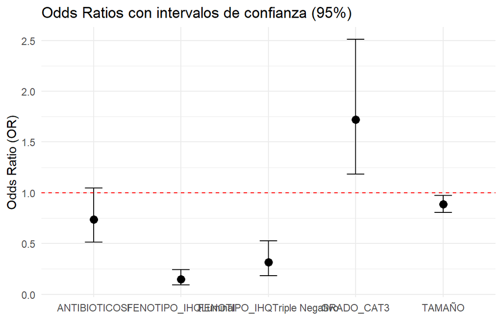

```r
# Paso 2: Visualizar OR con ggplot2
OR <- exp(coef(modelo_step))
CI <- exp(confint(modelo_step))
or_df <- data.frame(
  Variable = names(OR),
  OR = OR,
  CI_lower = CI[, 1],
  CI_upper = CI[, 2]
)

library(ggplot2)
ggplot(or_df[-1, ], aes(x = Variable, y = OR)) +  # Excluimos el intercepto
  geom_point(size = 3) +
  geom_errorbar(aes(ymin = CI_lower, ymax = CI_upper), width = 0.2) +
  geom_hline(yintercept = 1, linetype = "dashed", color = "red") +
  ylab("Odds Ratio (OR)") + xlab("") +
  ggtitle("Odds Ratios con intervalos de confianza (95%)") +
  theme_minimal()
```

```r
# Paso 3: Evaluar el desempeño del modelo con curva ROC
library(pROC)
roc_obj <- roc(datos$RCP_1, fitted(modelo_step))
```

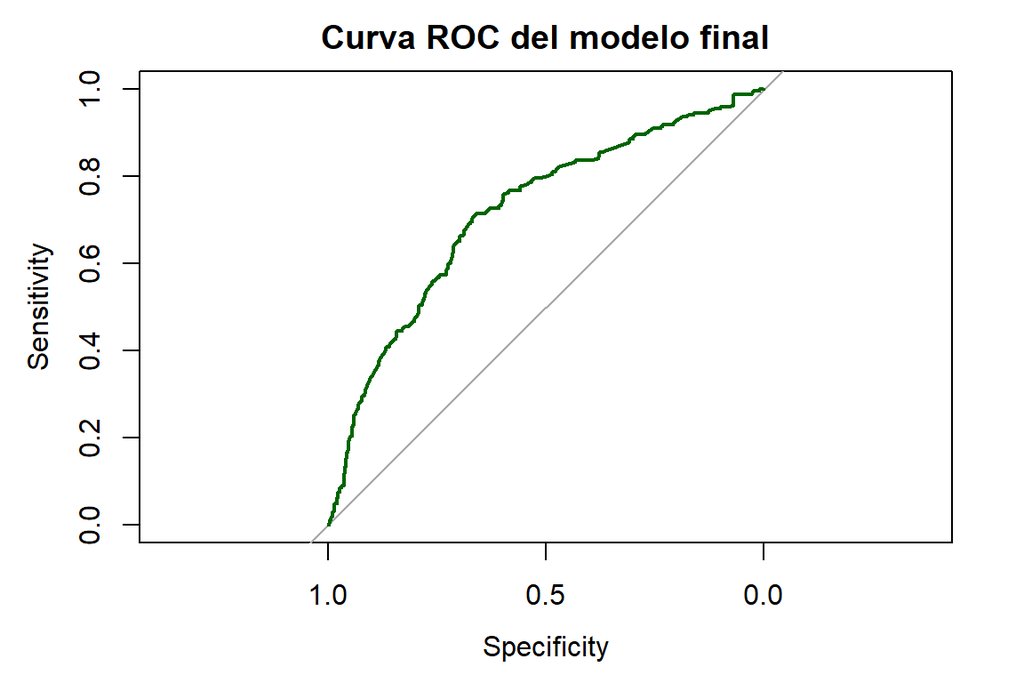

```r
plot(roc_obj, col = "darkgreen", lwd = 2, main = "Curva ROC del modelo final")
```

```r
auc(roc_obj)  # Área bajo la curva (AUC)
```

```
## Area under the curve: 0.7169
```

Por otro lado, el gráfico de odds ratios con intervalos de confianza al 95% nos da confianza sobre nuestros resultados.

Antes de darnos por satisfechos, haria falta tambien analizarlosin catergorizar las variables numéricas, para ver si el modelo funciona mejor.

```r
# Cargar librerías necesarias
library(MASS)



# Ajustar el modelo logístico con variables numéricas sin categorizar
modelo_numerico <- glm(RCP_bin ~ TAMAÑO + Ki67 + EDAD_DIAGNOSTICO + GRADO + RE + RP,
                       data = datos,
                       family = binomial)

# Ver resumen del modelo
summary(modelo_numerico)
```

```
##
## Call:
## glm(formula = RCP_bin ~ TAMAÑO + Ki67 + EDAD_DIAGNOSTICO + GRADO +
##     RE + RP, family = binomial, data = datos)
##
## Deviance Residuals:
##     Min       1Q   Median       3Q      Max
## -1.4022  -0.8384  -0.5398   1.1206   2.4344
##
## Coefficients:
##                   Estimate Std. Error z value Pr(>|z|)
## (Intercept)       0.472519   0.676218   0.699  0.48470
## TAMAÑO           -0.095352   0.048246  -1.976  0.04811 *
## Ki67              0.002578   0.003973   0.649  0.51641
## EDAD_DIAGNOSTICO -0.013771   0.007763  -1.774  0.07607 .
## GRADO             0.155020   0.180955   0.857  0.39163
## RE               -0.011455   0.002625  -4.364 1.27e-05 ***
## RP               -0.009862   0.003737  -2.639  0.00832 **
## ---
## Signif. codes:  0 '***' 0.001 '**' 0.01 '*' 0.05 '.' 0.1 ' ' 1
##
## (Dispersion parameter for binomial family taken to be 1)
##
##     Null deviance: 870.73  on 698  degrees of freedom
## Residual deviance: 770.29  on 692  degrees of freedom
## AIC: 784.29
##
## Number of Fisher Scoring iterations: 4
```

```r
# Aplicar selección automática de variables (backward)
modelo_numerico_back <- stepAIC(modelo_numerico, direction = "backward")
```

```
## Start:  AIC=784.29
## RCP_bin ~ TAMAÑO + Ki67 + EDAD_DIAGNOSTICO + GRADO + RE + RP
##
##                    Df Deviance    AIC
## - Ki67              1   770.71 782.71
## - GRADO             1   771.03 783.03
## <none>                  770.29 784.29
## - EDAD_DIAGNOSTICO  1   773.46 785.46
## - TAMAÑO            1   774.33 786.33
## - RP                1   777.51 789.51
## - RE                1   790.58 802.58
##
## Step:  AIC=782.71
## RCP_bin ~ TAMAÑO + EDAD_DIAGNOSTICO + GRADO + RE + RP
##
##                    Df Deviance    AIC
## - GRADO             1   771.99 781.99
## <none>                  770.71 782.71
## - EDAD_DIAGNOSTICO  1   774.11 784.11
## - TAMAÑO            1   774.80 784.80
## - RP                1   778.21 788.21
## - RE                1   793.20 803.20
##
## Step:  AIC=781.99
## RCP_bin ~ TAMAÑO + EDAD_DIAGNOSTICO + RE + RP
##
##                    Df Deviance    AIC
## <none>                  771.99 781.99
## - EDAD_DIAGNOSTICO  1   775.74 783.74
## - TAMAÑO            1   775.95 783.95
## - RP                1   780.09 788.09
## - RE                1   799.27 807.27
```

```r
# Mostrar resumen del modelo final
summary(modelo_numerico_back)
```

```
##
## Call:
## glm(formula = RCP_bin ~ TAMAÑO + EDAD_DIAGNOSTICO + RE + RP,
##     family = binomial, data = datos)
##
## Deviance Residuals:
##     Min       1Q   Median       3Q      Max
## -1.3775  -0.8439  -0.5375   1.1171   2.4902
##
## Coefficients:
##                   Estimate Std. Error z value Pr(>|z|)
## (Intercept)       1.089841   0.456078   2.390  0.01687 *
## TAMAÑO           -0.094191   0.048175  -1.955  0.05056 .
## EDAD_DIAGNOSTICO -0.014834   0.007701  -1.926  0.05408 .
## RE               -0.012513   0.002498  -5.010 5.43e-07 ***
## RP               -0.010357   0.003713  -2.790  0.00528 **
## ---
## Signif. codes:  0 '***' 0.001 '**' 0.01 '*' 0.05 '.' 0.1 ' ' 1
##
## (Dispersion parameter for binomial family taken to be 1)
##
##     Null deviance: 870.73  on 698  degrees of freedom
## Residual deviance: 771.99  on 694  degrees of freedom
## AIC: 781.99
##
## Number of Fisher Scoring iterations: 4
```

Esta comparación responde a una necesidad metodológica clave: determinar si la transformación de variables (como el tamaño tumoral, los receptores hormonales o el índice Ki67) en categorías clínicas aporta claridad interpretativa sin comprometer el ajuste del modelo, o si, por el contrario, implica una pérdida de información que afecta su rendimiento predictivo. Los resultados muestran que el modelo con variables continuas presenta un AIC menor (781.99) frente al modelo con variables categorizadas (AIC = 794.56), lo que indica una mejor capacidad de ajuste y menor pérdida de información. Esto se debe a que las variables continuas permiten capturar variaciones más sutiles en los datos, especialmente en contextos donde la relación con la RCP puede ser más compleja que una simple dicotomía.

# 7 Análisis de Supervivencia

En estudios clínicos oncológicos, no solo resulta relevante saber si un evento ocurre, sino cuándo ocurre. El análisis de supervivencia responde precisamente a esta necesidad, permitiendo modelar el tiempo hasta la aparición de un evento de interés, teniendo en cuenta tanto los pacientes que experimentan dicho evento como aquellos que, por diversas razones, no lo hacen durante el seguimiento (pacientes censurados).

Este enfoque aporta una ventaja fundamental respecto a modelos tradicionales como la regresión logística, ya que incorpora la dimensión temporal y es capaz de manejar información incompleta de forma adecuada. En el caso clínico que nos ocupa, el evento considerado es el fallecimiento, y el objetivo es estimar la probabilidad de supervivencia global (SG) a lo largo del tiempo.

## 7.1 Concepto de función de supervivencia

La función de supervivencia, denotada por \( S(t) \), representa la probabilidad de que un individuo sobreviva más allá del tiempo \( t \). Se define como:

$$S(t) = P(T > t)$$

donde \( T \) es una variable aleatoria que representa el tiempo hasta el evento. Esta función decrece con el tiempo y su estimación práctica se realiza mediante el método no paramétrico de **Kaplan-Meier**, que proporciona una curva escalonada reflejando la probabilidad acumulada de supervivencia.

En nuestro estudio, se define como evento de interés el fallecimiento por cáncer de mama. Esta información se encuentra codificada en la variable ESTADO_ULTIMO_CONTROL, que recoge el estado vital de cada paciente al momento del último seguimiento. Se considera que ha ocurrido un evento (evento = 1) cuando ESTADO_ULTIMO_CONTROL == “MCE” (muerte por causa de la enfermedad). En todos los demás casos, el paciente se considera censurado (evento = 0), incluyendo aquellas que permanecen vivas (VSE), aquellas fallecidas por otras causas o las que abandonaron el seguimiento antes de observarse un evento.

Además del estado vital, el análisis de supervivencia requiere conocer el tiempo exacto de seguimiento de cada paciente, que se calcula como la diferencia entre la fecha de diagnóstico (FECHA_DIAGNOSTICO) y la fecha del último control clínico (FECHA_ULTIMO_CONTROL), ambas expresadas en años para mayor claridad en la interpretación.

A continuación, se presenta el código empleado para construir el objeto de análisis y visualizar la curva de supervivencia global para toda la cohorte:

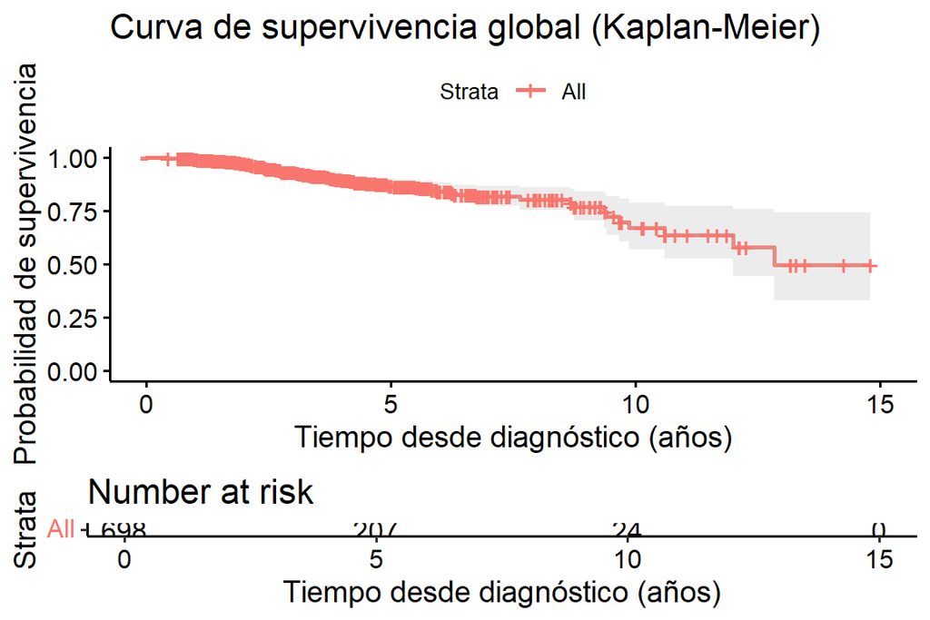

```r
#  Limpiar saltos de línea, retorno de carro y espacios
names(datos) <- gsub("[\\r\\n]", "", names(datos))
names(datos) <- trimws(names(datos))

#  Renombrar la columna de estado si es necesario
names(datos)[names(datos) == "ESTADO_ULTIMO_CONTROL"] <- "ESTADO_ULTIMO_
CONTROL"

# Cargar librerías necesarias
library(survival)
library(survminer)
library(lubridate)
library(dplyr)

# Limpiar nombres de columnas de caracteres especiales
names(datos) <- gsub("[\r\n]", "", names(datos))
names(datos) <- trimws(names(datos))

# Renombrar columna que contiene "ESTADO_ULTIMO"
col_estado <- grep("ESTADO_ULTIMO", names(datos), value = TRUE)
names(datos)[names(datos) == col_estado] <- "ESTADO_ULTIMO_CONTROL"

# Convertir fechas al formato correcto
datos$FECHA_DIAGNOSTICO <- dmy(datos$FECHA_DIAGNOSTICO)
datos$FECHA_ULTIMO_CONTROL <- dmy(datos$FECHA_ULTIMO_CONTROL)

# Calcular tiempo de seguimiento en años
datos$tiempo_SG <- as.numeric(difftime(datos$FECHA_ULTIMO_CONTROL,
                                       datos$FECHA_DIAGNOSTICO,
                                       units = "days")) / 365.25

# Crear variable de evento (1 si falleció, 0 si censurado)
datos$evento_SG <- ifelse(datos$ESTADO_ULTIMO_CONTROL == "MCE", 1, 0)

# Crear objeto de supervivencia
surv_object <- Surv(time = datos$tiempo_SG, event = datos$evento_SG)

# Ajustar modelo Kaplan-Meier
km_fit <- survfit(surv_object ~ 1)

# Graficar curva de supervivencia
ggsurvplot(km_fit,
           data = datos,
           risk.table = TRUE,
           xlab = "Tiempo desde diagnóstico (años)",
           ylab = "Probabilidad de supervivencia",
           title = "Curva de supervivencia global (Kaplan-Meier)",
           conf.int = TRUE)
```

En el eje horizontal se representa el tiempo transcurrido desde el diagnóstico (en años), mientras que el eje vertical muestra la probabilidad acumulada de supervivencia. Las marcas verticales indican casos censurados, es decir, pacientes que no han experimentado el evento (muerte) al finalizar el seguimiento.

En la parte inferior del gráfico se muestra la tabla de riesgo, que indica el número de pacientes aún en seguimiento (no censurados ni fallecidos) en distintos momentos del tiempo.¿Qué nos dice esta tabla?

A 15 años: 0 personas → el seguimiento se ha completado o censurado para todos

```r
# Probabilidad de supervivencia a 2, 5 y 10 años
prob_2 <- summary(km_fit, times = 2)$surv
prob_5 <- summary(km_fit, times = 5)$surv
prob_10 <- summary(km_fit, times = 10)$surv

# Mediana de supervivencia
mediana_supervivencia <- summary(km_fit)$table["median"]

# Mostrar resultados clave
cat("📌 Mediana de supervivencia:", round(mediana_supervivencia, 2), "años\n")
```

```
## 📌 Mediana de supervivencia: 12.84 años
```

```r
cat("📈 Probabilidad de estar viva a 2 años:", round(prob_2, 3), "\n")
```

```
## 📈 Probabilidad de estar viva a 2 años: 0.974
```

```r
cat("📈 Probabilidad de estar viva a 5 años:", round(prob_5, 3), "\n")
```

```
## 📈 Probabilidad de estar viva a 5 años: 0.87
```

```r
cat("📈 Probabilidad de estar viva a 10 años:", round(prob_10, 3), "\n")
```

```
## 📈 Probabilidad de estar viva a 10 años: 0.671
```

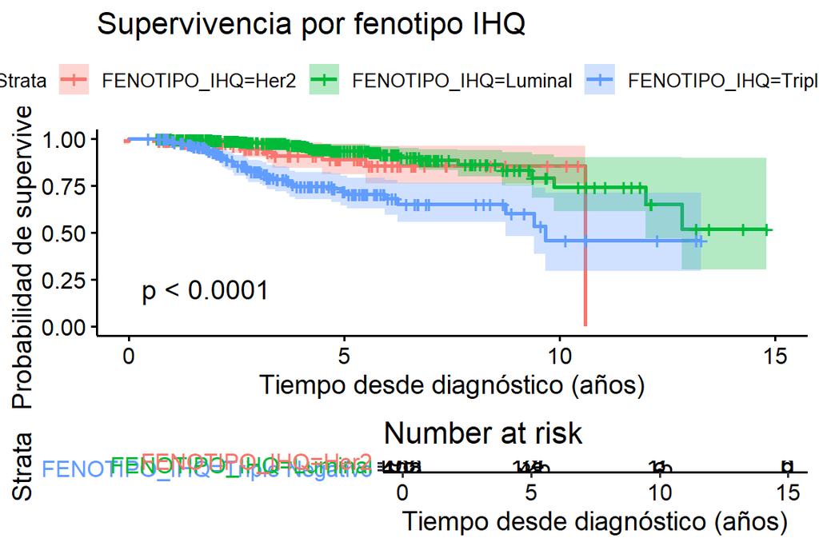

```r
# 📂 Comparación entre grupos clínicos (ej. FENOTIPO_IHQ)
km_grupos <- survfit(surv_object ~ FENOTIPO_IHQ, data = datos)

# Gráfico por grupos
ggsurvplot(km_grupos,
           data = datos,
           risk.table = TRUE,
           pval = TRUE,
           conf.int = TRUE,
           xlab = "Tiempo desde diagnóstico (años)",
           ylab = "Probabilidad de supervivencia",
           title = "Supervivencia por fenotipo IHQ")
```

```r
# ⚖️ Test de log-rank para diferencias entre grupos
test_logrank <- survdiff(surv_object ~ FENOTIPO_IHQ, data = datos)
print(test_logrank)
```

```
## Call:
## survdiff(formula = surv_object ~ FENOTIPO_IHQ, data = datos)
##
##                                N Observed Expected (O-E)^2/E (O-E)^2/V
## FENOTIPO_IHQ=Her2             99        9     10.3     0.157     0.182
## FENOTIPO_IHQ=Luminal         408       25     48.0    11.052    28.867
## FENOTIPO_IHQ=Triple Negativo 192       44     19.7    30.018    40.248
##
##  Chisq= 41.3  on 2 degrees of freedom, p= 1e-09
```

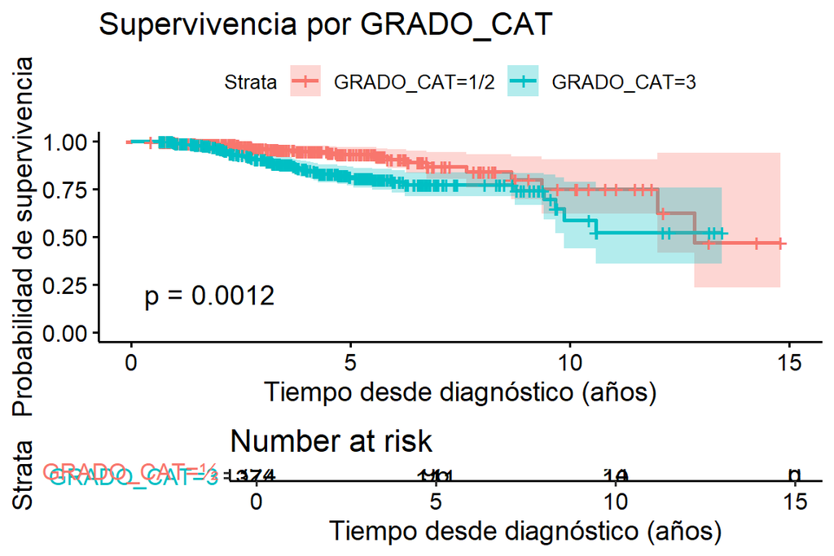

```r
# 📂 Comparación entre grupos clínicos
km_grupos <- survfit(surv_object ~ GRADO_CAT , data = datos)

# Gráfico por grupos
ggsurvplot(km_grupos,
           data = datos,
           risk.table = TRUE,
           pval = TRUE,
           conf.int = TRUE,
           xlab = "Tiempo desde diagnóstico (años)",
           ylab = "Probabilidad de supervivencia",
           title = "Supervivencia por GRADO_CAT")
```

```r
# ⚖️ Test de log-rank para diferencias entre grupos
test_logrank <- survdiff(surv_object ~ GRADO_CAT, data = datos)
print(test_logrank)
```

```
## Call:
## survdiff(formula = surv_object ~ GRADO_CAT, data = datos)
##
##                 N Observed Expected (O-E)^2/E (O-E)^2/V
## GRADO_CAT=1/2 325       23     37.3      5.50      10.6
## GRADO_CAT=3   374       55     40.7      5.04      10.6
##
##  Chisq= 10.6  on 1 degrees of freedom, p= 0.001
```

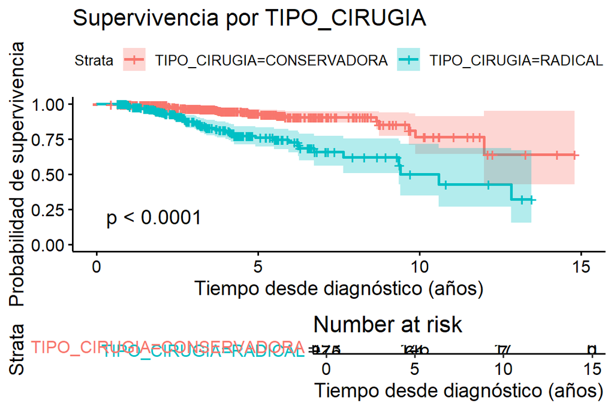

```r
# 📂 Comparación entre grupos clínicos
km_grupos <- survfit(surv_object ~ TIPO_CIRUGIA , data = datos)

# Gráfico por grupos
ggsurvplot(km_grupos,
           data = datos,
           risk.table = TRUE,
           pval = TRUE,
           conf.int = TRUE,
           xlab = "Tiempo desde diagnóstico (años)",
           ylab = "Probabilidad de supervivencia",
           title = "Supervivencia por TIPO_CIRUGIA")
```

```r
# ⚖️ Test de log-rank para diferencias entre grupos
test_logrank <- survdiff(surv_object ~ TIPO_CIRUGIA, data = datos)
print(test_logrank)
```

```
## Call:
## survdiff(formula = surv_object ~ TIPO_CIRUGIA, data = datos)
##
##                             N Observed Expected (O-E)^2/E (O-E)^2/V
## TIPO_CIRUGIA=CONSERVADORA 424       27     51.4      11.6      34.1
## TIPO_CIRUGIA=RADICAL      275       51     26.6      22.3      34.1
##
##  Chisq= 34.1  on 1 degrees of freedom, p= 5e-09
```

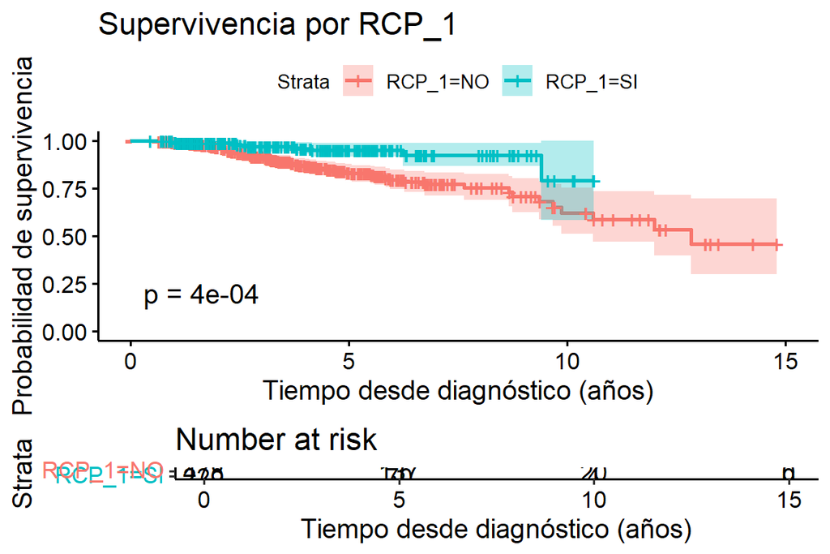

```r
# 📂 Comparación entre grupos clínicos
km_grupos <- survfit(surv_object ~ RCP_1 , data = datos)

# Gráfico por grupos
ggsurvplot(km_grupos,
           data = datos,
           risk.table = TRUE,
           pval = TRUE,
           conf.int = TRUE,
           xlab = "Tiempo desde diagnóstico (años)",
           ylab = "Probabilidad de supervivencia",
           title = "Supervivencia por RCP_1")
```

```r
# ⚖️ Test de log-rank para diferencias entre grupos
test_logrank <- survdiff(surv_object ~ RCP_1, data = datos)
print(test_logrank)
```

```
## Call:
## survdiff(formula = surv_object ~ RCP_1, data = datos)
##
##            N Observed Expected (O-E)^2/E (O-E)^2/V
## RCP_1=NO 479       69     54.8      3.66      12.5
## RCP_1=SI 220        9     23.2      8.66      12.5
##
##  Chisq= 12.5  on 1 degrees of freedom, p= 4e-04
```

Finalmente, los pacientes que lograron respuesta completa patológica (RCP_1 = “SI”) presentan una supervivencia notablemente mayor en comparación con aquellos que no la alcanzaron. También se observa que los pacientes sometidos a cirugía conservadora tienen una mayor probabilidad de supervivencia que aquellos que recibieron cirugía radical, lo que puede reflejar un mejor estadio inicial o una mejor respuesta al tratamiento neoadyuvante. Asimismo, los tumores de menor grado histológico (GRADO_CAT = 1/2) están asociados a una mejor supervivencia que los de alto grado (GRADO_CAT = 3). Por último, el análisis por fenotipo IHQ revela que el subtipo Luminal presenta el mejor pronóstico, seguido de Her2, mientras que el triple negativo muestra la supervivencia más baja. Todas estas diferencias fueron estadísticamente significativas (p < 0.05), lo que resalta la importancia de estas variables como factores pronóstico clave en el manejo del cáncer de mama.